# Bias adjustment in VICAR

David Gerard

2016-07-14

# Abstract

In addition to variance inflation, I perform bias correction in the second step of VICAR. I find that there is a small improvement in terms of AUC but little difference, and perhaps slightly worse performance, in estimating $\pi_0$.

# Details

When estimating the empirical null, Efron (2004) and Iterson et al. (2016) also estimate the mean of the empirical null to correct for bias in the test statistics. Motivated by this, we replace the second equation of VICAR with \begin{align} \boldsymbol{Y}_{2\mathcal{C}} &= \boldsymbol{\mu}\boldsymbol{1}_p^T + \boldsymbol{Z}_2\hat{\boldsymbol{\alpha}}_{\mathcal{C}} + \boldsymbol{E}_{2\mathcal{C}}, \end{align}

where $\boldsymbol{\mu} \in \mathbb{R}^{k_2}$ is the bias and $\boldsymbol{1}_p$ is a $p$-vector of $1$’s. We then estimate $\boldsymbol{\mu}$ along with $\boldsymbol{Z}_2$ and $\lambda$. However, this is equivalent to just setting $\tilde{\boldsymbol{\alpha}} = {{\boldsymbol{1}_p^T}\choose{\hat{\boldsymbol{\alpha}}}}$ and estimating $(\boldsymbol{\mu}, \boldsymbol{Z}_2)$ with the previously described variance inflation method using $\tilde{\boldsymbol{\alpha}}$ instead of $\hat{\boldsymbol{\alpha}}$

# Results

## `ashr` $\hat{\pi}_0$

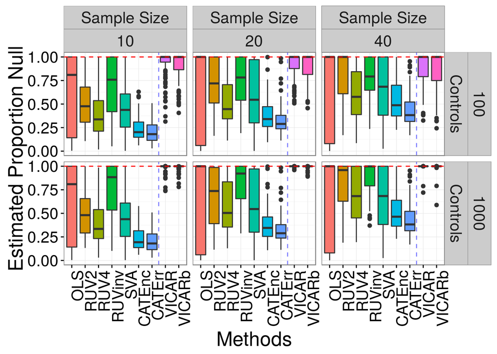

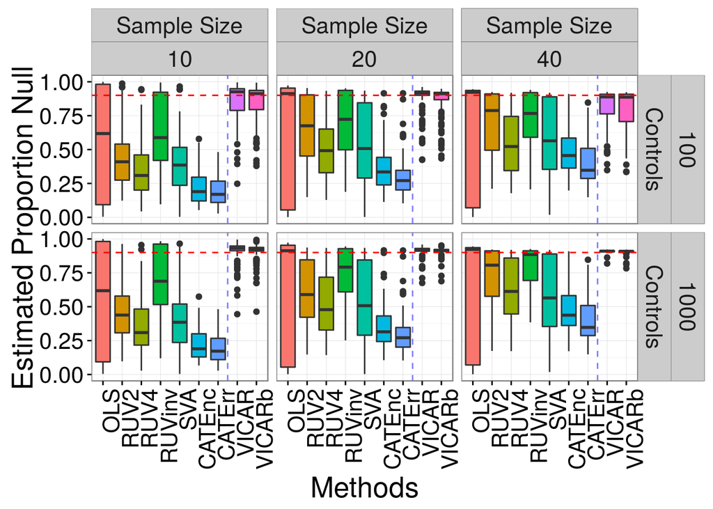

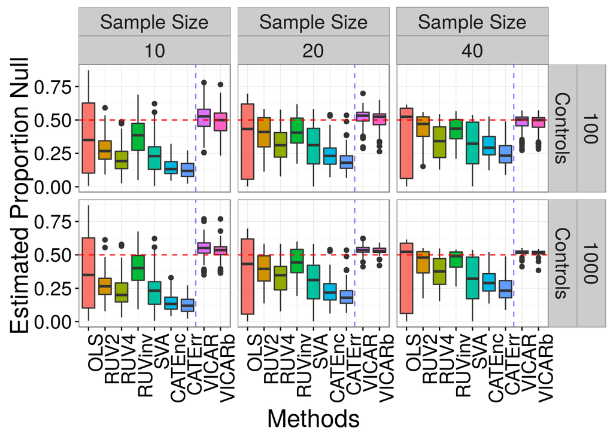

## `qvalue` $\hat{\pi}_0$

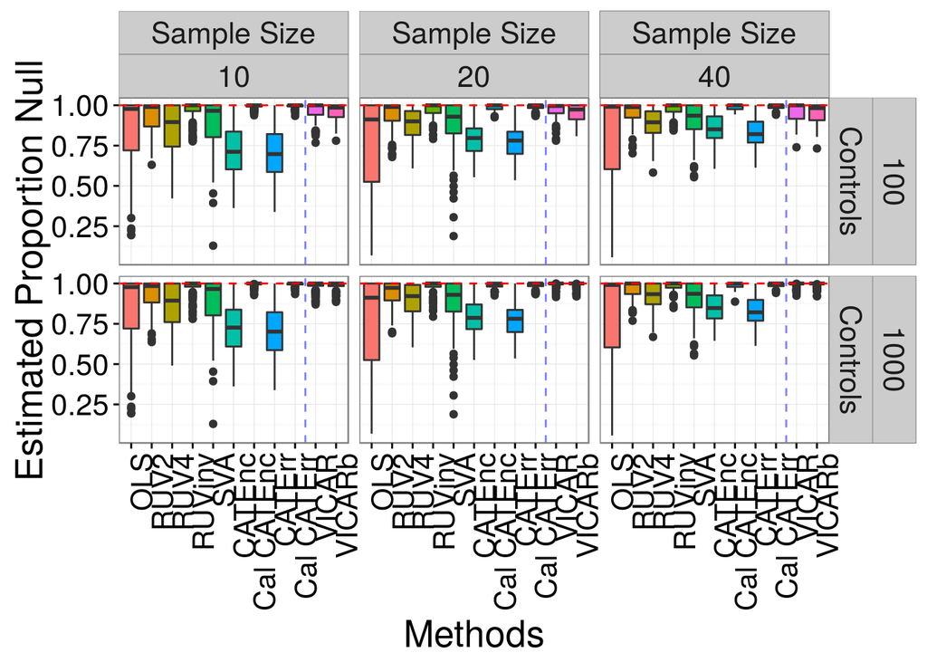

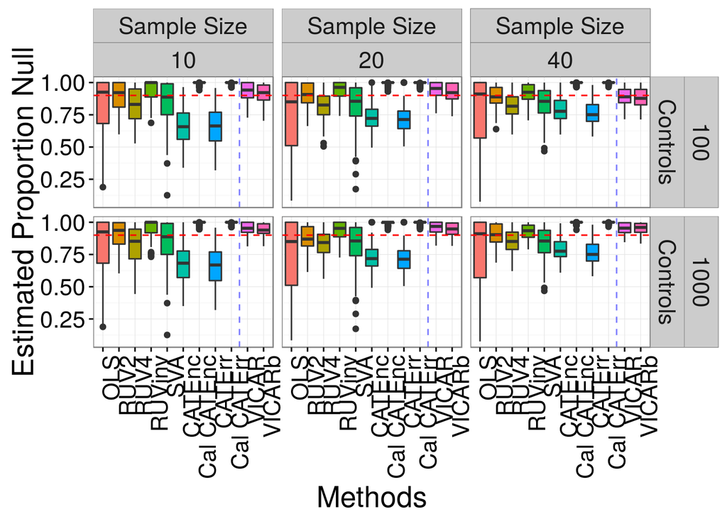

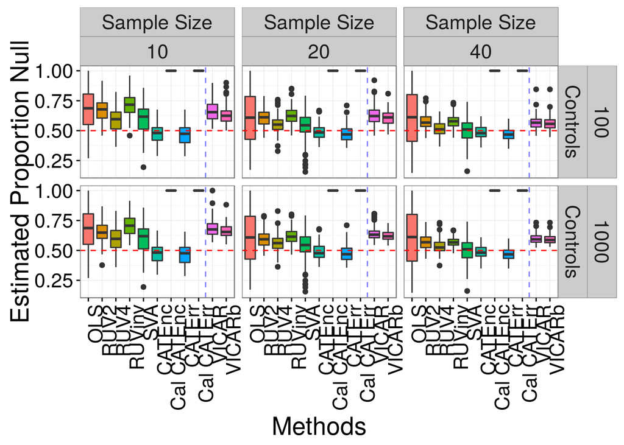

## `ashr` AUC

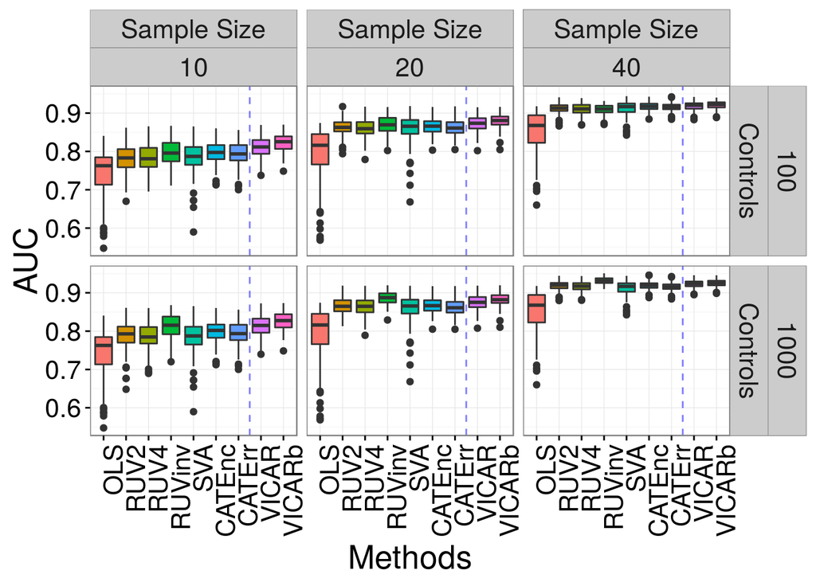

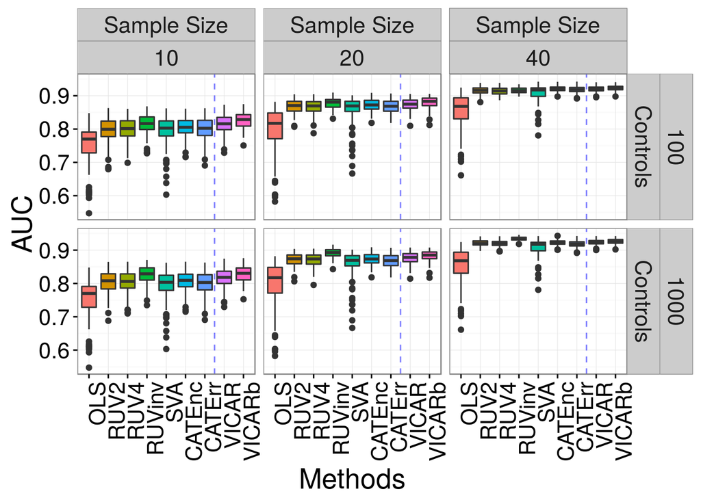

## pvalues AUC

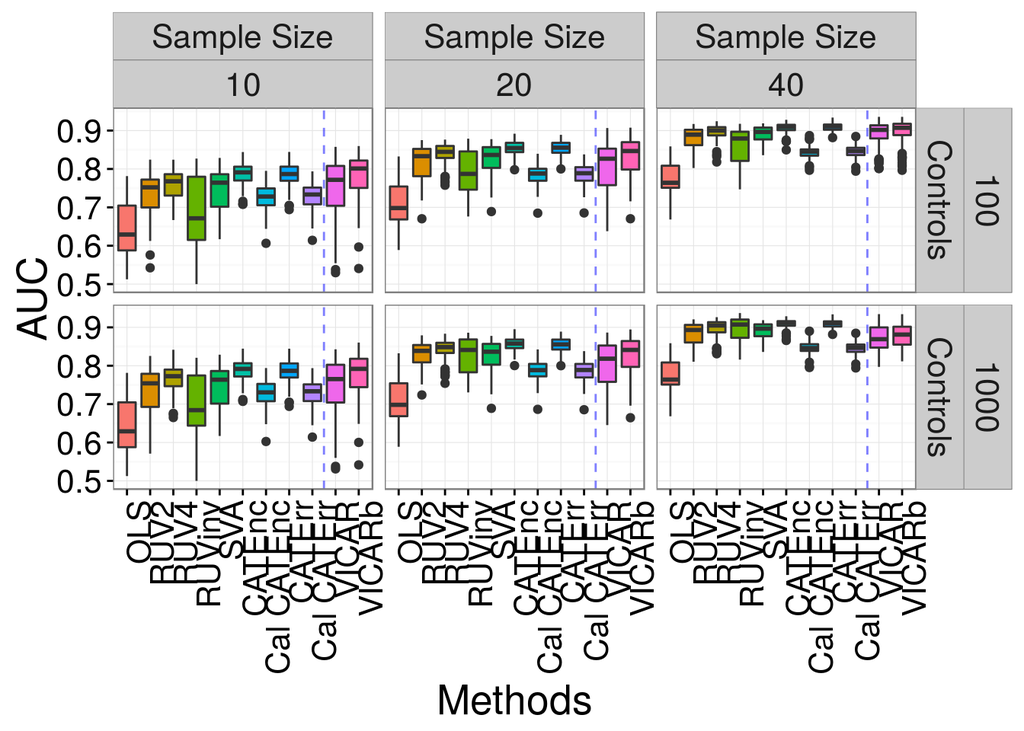

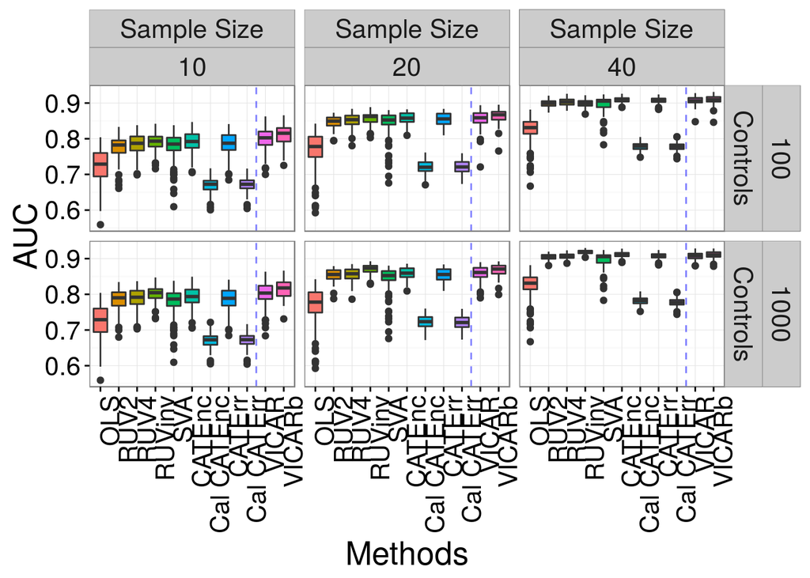

# References

Efron, Bradley. 2004. “Large-Scale Simultaneous Hypothesis Testing.” *Journal of the American Statistical Association*. Taylor & Francis, 96–104. doi:10.1198/016214504000000089.

Iterson, Maarten M van, Erik W van Zwet, P Eline Slagboom, Bastiaan T Heijmans, Bios Consortium, and others. 2016. “Controlling Bias and Inflation in Epigenome-and Transcriptome-Wide Association Studies Using the Empirical Null Distribution.” *BioRxiv*. Cold Spring Harbor Labs Journals, 055772.